# OncoScan: Mutation-Outcome Association Explorer in Breast Cancer (METABRIC)

Kennedy Kasonde

2026-09-29

# Introduction

Breast cancer is a molecularly heterogeneous disease, and mutations in key driver genes are known to associate with distinct clinical phenotypes and prognosis. This report explores somatic mutation data from the METABRIC cohort (Curtis et al., 2012; Pereira et al., 2016) to characterize mutation frequency across a curated oncogene panel and test whether mutation status in these genes is associated with the Nottingham Prognostic Index (NPI), a composite clinical score combining tumor size, grade, and nodal status.

This analysis is exploratory and statistical in nature — it does not involve machine learning or predictive modeling. All data wrangling uses the `tidyverse` (`dplyr`, `stringr`, `forcats`), and all statistical testing uses base R with multiple-testing correction via `p.adjust(method = "BH")`.

**Data source:** METABRIC cohort, accessed via cBioPortal (https://www.cbioportal.org/study/summary?id=brca_metabric).

# Data Loading and Cleaning

```r
Data <- read_csv("data/METABRIC_RNA_Mutation.csv")
glimpse(Data)
```

```
## Rows: 1,904
## Columns: 693
## $ patient_id                     <dbl> 0, 2, 5, 6, 8, 10, 14, 22, 28, 35, 36, …
## $ age_at_diagnosis               <dbl> 75.65, 43.19, 48.87, 47.68, 76.97, 78.7…
## $ type_of_breast_surgery         <chr> "MASTECTOMY", "BREAST CONSERVING", "MAS…
## $ cancer_type                    <chr> "Breast Cancer", "Breast Cancer", "Brea…
## $ cancer_type_detailed           <chr> "Breast Invasive Ductal Carcinoma", "Br…
## $ cellularity                    <chr> NA, "High", "High", "Moderate", "High",…
## $ chemotherapy                   <dbl> 0, 0, 1, 1, 1, 0, 1, 0, 0, 0, 0, 0, 1, …
## $ `pam50_+_claudin-low_subtype`  <chr> "claudin-low", "LumA", "LumB", "LumB", …
## $ cohort                         <dbl> 1, 1, 1, 1, 1, 1, 1, 1, 1, 1, 1, 1, 1, …
## $ er_status_measured_by_ihc      <chr> "Positve", "Positve", "Positve", "Posit…
## $ er_status                      <chr> "Positive", "Positive", "Positive", "Po…
## $ neoplasm_histologic_grade      <dbl> 3, 3, 2, 2, 3, 3, 2, 2, 3, 2, 2, 1, 3, …
## $ her2_status_measured_by_snp6   <chr> "NEUTRAL", "NEUTRAL", "NEUTRAL", "NEUTR…
```

[output cut: 680 more lines]

## Clinical data preparation

We select the clinical variables relevant to this analysis and derive a triple-negative breast cancer (TNBC) status flag from receptor status columns. `death_from_cancer` contains blank strings rather than proper `NA`s in the raw export, so these are converted explicitly before further use.

```r
Data$death_from_cancer <- na_if(Data$death_from_cancer, "")

clinical_data <- Data %>%
  select(patient_id, age_at_diagnosis, tumor_size, tumor_stage,
         er_status, pr_status, her2_status,
         overall_survival_months, overall_survival, death_from_cancer,
         nottingham_prognostic_index, mutation_count,
         chemotherapy, hormone_therapy, radio_therapy) %>%
  mutate(
    triple_negative_status = case_when(
      er_status == "Negative" & pr_status == "Negative" & her2_status == "Negative" ~ "TNBC",
      TRUE ~ "Non-TNBC"
    )
  )

glimpse(clinical_data)
```

```
## Rows: 1,904
## Columns: 16
## $ patient_id                  <dbl> 0, 2, 5, 6, 8, 10, 14, 22, 28, 35, 36, 39,…
## $ age_at_diagnosis            <dbl> 75.65, 43.19, 48.87, 47.68, 76.97, 78.77, …
## $ tumor_size                  <dbl> 22, 10, 15, 25, 40, 31, 10, 29, 16, 28, 22…
## $ tumor_stage                 <dbl> 2, 1, 2, 2, 2, 4, 2, 2, 2, 2, 4, 1, 2, 2, …
## $ er_status                   <chr> "Positive", "Positive", "Positive", "Posit…
## $ pr_status                   <chr> "Negative", "Positive", "Positive", "Posit…
## $ her2_status                 <chr> "Negative", "Negative", "Negative", "Negat…
## $ overall_survival_months     <dbl> 140.50000, 84.63333, 163.70000, 164.93333,…
## $ overall_survival            <dbl> 1, 1, 0, 1, 0, 0, 1, 0, 0, 0, 0, 1, 1, 0, …
## $ death_from_cancer           <chr> "Living", "Living", "Died of Disease", "Li…
## $ nottingham_prognostic_index <dbl> 6.044, 4.020, 4.030, 4.050, 6.080, 4.062, …
## $ mutation_count              <dbl> NA, 2, 2, 1, 2, 4, 4, 1, 4, 5, 1, 3, NA, 2…
## $ chemotherapy                <dbl> 0, 0, 1, 1, 1, 0, 1, 0, 0, 0, 0, 0, 1, 0, …
## $ hormone_therapy             <dbl> 1, 1, 1, 1, 1, 1, 1, 1, 1, 0, 1, 1, 0, 1, …
## $ radio_therapy               <dbl> 1, 1, 0, 1, 1, 1, 1, 1, 1, 0, 1, 1, 1, 1, …
## $ triple_negative_status      <chr> "Non-TNBC", "Non-TNBC", "Non-TNBC", "Non-T…
```

## Oncogene panel definition

A 15-gene panel of well-characterized breast cancer oncogenes and tumor suppressors was selected and verified against the dataset’s column names before use.

```r
oncogene_panel <- c("tp53", "brca1", "brca2", "pik3ca", "kras", "braf",
                     "egfr", "chek2", "akt2", "cdkn2a", "gata3", "cdh1",
                     "map3k1", "erbb2", "pten")

mut_cols <- paste0(oncogene_panel, "_mut")
stopifnot(length(setdiff(mut_cols, colnames(Data))) == 0)
```

## Mutation data reshaping

Mutation columns are stored in wide format, with `"0"` indicating no mutation and any other value containing the protein-change annotation (e.g., `"R175H"`). We reshape to long format and classify each mutated entry by variant type using `str_detect()` on the annotation text.

**Note on scope:** a small number of cells (~240 of 2,344 mutated instances, ~10%, concentrated in PIK3CA and MAP3K1) contain multiple co-occurring mutations in the same gene. These are classified by the first-matching pattern in the `case_when()` below rather than split into separate events — a documented simplification (see Limitations).

```r
mutation_long <- Data %>%
  select(patient_id, all_of(mut_cols)) %>%
  pivot_longer(
    cols = all_of(mut_cols),
    names_to = "gene",
    values_to = "mutation_detail"
  ) %>%
  mutate(
    gene = str_remove(gene, "_mut"),
    mutated = mutation_detail != "0",
    mutation_type = case_when(
      mutation_detail == "0" ~ "None",
      str_detect(mutation_detail, "fs") ~ "Frameshift",
      str_detect(mutation_detail, "_splice") ~ "Splice site",
      str_detect(mutation_detail, "\\*") ~ "Nonsense",
      str_detect(mutation_detail, "del") ~ "In-frame deletion",
      TRUE ~ "Missense"
    )
  )
```

# Results

## Mutation frequency across the oncogene panel

```r
gene_freq <- mutation_long %>%
  filter(mutated) %>%
  count(gene, name = "n_mutated", sort = TRUE) %>%
  mutate(
    pct_patients = n_mutated / nrow(clinical_data) * 100,
    gene = str_to_upper(gene)
  )
```

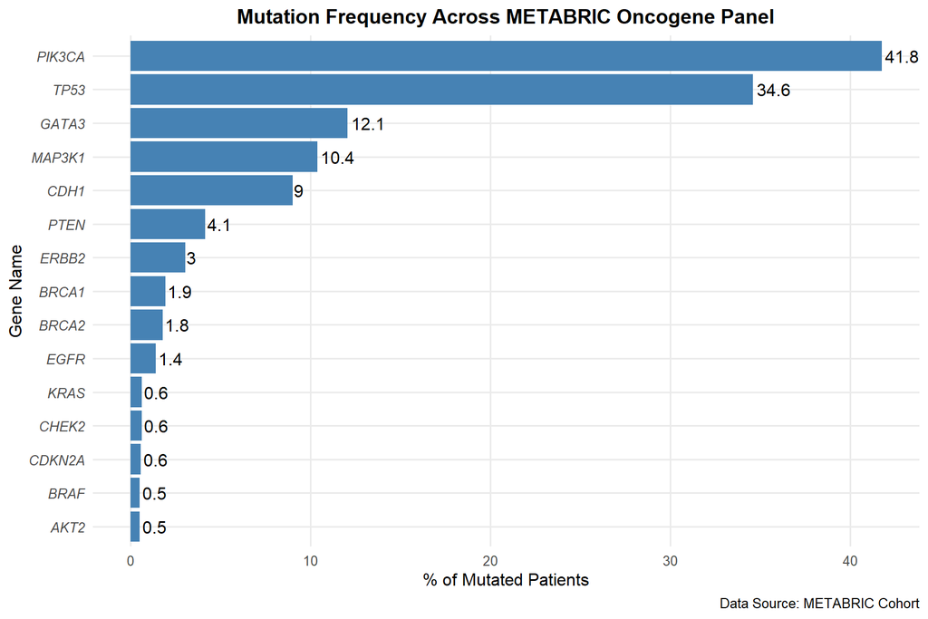

Figure 1: Mutation frequency across the METABRIC oncogene panel.

```r
ggplot(gene_freq, aes(x = fct_reorder(gene, n_mutated), y = pct_patients)) +
  geom_col(fill = "steelblue") +
  geom_text(aes(label = round(pct_patients, 1)), hjust = -0.1) +
  coord_flip() +
  labs(
    title = "Mutation Frequency Across METABRIC Oncogene Panel",
    x = "Gene Name", y = "% of Mutated Patients",
    caption = "Data Source: METABRIC Cohort"
  ) +
  theme_minimal(base_size = 12) +
  theme(
    plot.title = element_text(face = "bold", size = 14, hjust = 0.5),
    panel.grid.minor = element_blank(),
    axis.text.y = element_text(face = "italic")
  )
```

PIK3CA (41.8%) and TP53 (34.6%) are the most frequently mutated genes in this cohort, consistent with published METABRIC mutation frequencies (Pereira et al., 2016). Genes such as KRAS, BRAF, and AKT2 show very low mutation frequency here, consistent with their more prominent driver role in other cancer types rather than breast cancer specifically.

## Clinical stratification

```r
clinical_plot_data <- clinical_data %>%
  filter(!is.na(tumor_stage)) %>%
  mutate(tumor_stage = factor(tumor_stage))
```

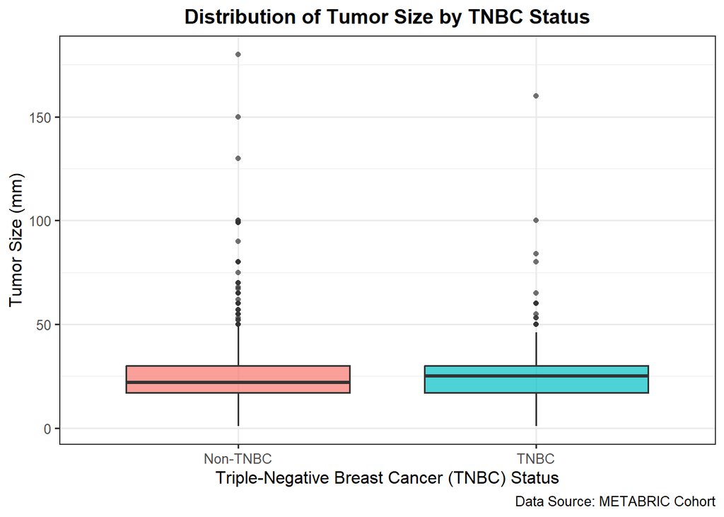

Figure 2: Tumor size by TNBC status.

```r
ggplot(clinical_plot_data, aes(x = triple_negative_status, y = tumor_size,
                                fill = triple_negative_status)) +
  geom_boxplot(alpha = 0.7, outlier.shape = 16, outlier.size = 1.5) +
  labs(
    title = "Distribution of Tumor Size by TNBC Status",
    x = "Triple-Negative Breast Cancer (TNBC) Status", y = "Tumor Size (mm)",
    caption = "Data Source: METABRIC Cohort"
  ) +
  theme_bw(base_size = 12) +
  theme(plot.title = element_text(face = "bold", size = 14, hjust = 0.5),
        legend.position = "none")
```

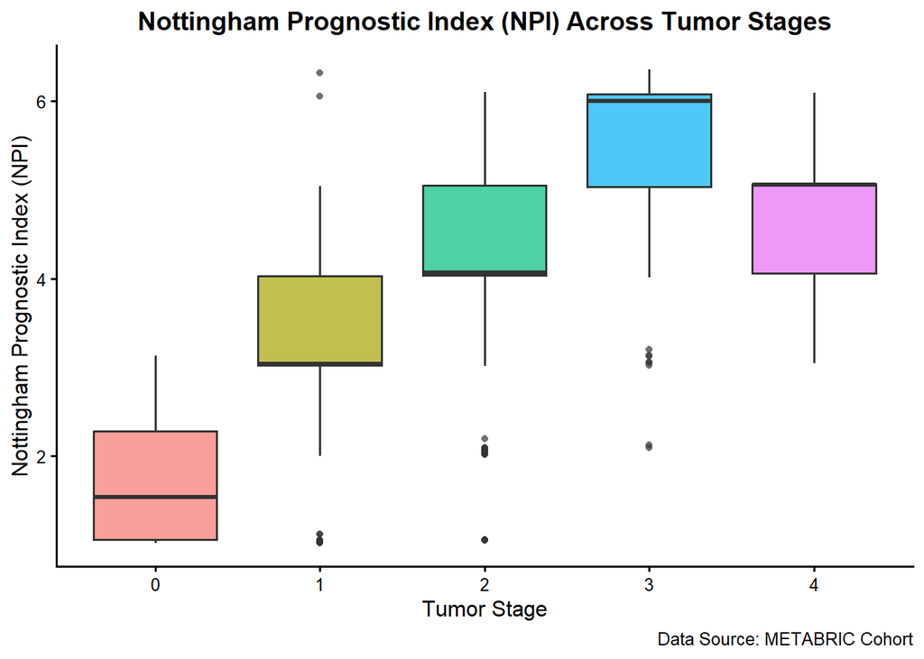

Figure 3: NPI across tumor stages.

```r
ggplot(clinical_plot_data, aes(x = tumor_stage, y = nottingham_prognostic_index,
                                fill = tumor_stage)) +
  geom_boxplot(alpha = 0.7, outlier.shape = 16, outlier.size = 1.5) +
  labs(
    title = "Nottingham Prognostic Index (NPI) Across Tumor Stages",
    x = "Tumor Stage", y = "Nottingham Prognostic Index (NPI)",
    caption = "Data Source: METABRIC Cohort"
  ) +
  theme_classic(base_size = 12) +
  theme(plot.title = element_text(face = "bold", size = 14, hjust = 0.5),
        legend.position = "none")
```

NPI increases consistently with tumor stage from Stage 0 through Stage 3. Stage 4 (n = 9) shows a lower median NPI than Stage 3; given the very small sample size at this stage, and that NPI does not directly incorporate metastatic spread (unlike overall tumor staging), this pattern should be interpreted cautiously rather than as a contradiction.

## Statistical association: mutation status and prognostic score

For each gene in the panel, patients were split into mutated vs. non-mutated groups and compared on NPI using Welch’s t-test. Raw p-values were adjusted across all 15 tests using the Benjamini-Hochberg procedure to control the false discovery rate.

```r
mutation_clinical <- mutation_long %>%
  filter(gene %in% oncogene_panel) %>%
  select(patient_id, gene, mutated) %>%
  left_join(
    clinical_data %>% select(patient_id, nottingham_prognostic_index),
    by = "patient_id"
  )
```

```r
gene_results <- mutation_clinical %>%
  group_by(gene) %>%
  group_modify(~ {
    npi_mut    <- .x$nottingham_prognostic_index[.x$mutated]
    npi_nonmut <- .x$nottingham_prognostic_index[!.x$mutated]

    test_result <- tryCatch(
      t.test(npi_mut, npi_nonmut),
      error = function(e) NULL
    )

    if (is.null(test_result)) {
      tibble(n_mutated = sum(.x$mutated), mean_diff = NA_real_, p_value = NA_real_)
    } else {
      tibble(
        n_mutated = sum(.x$mutated),
        mean_diff = mean(npi_mut) - mean(npi_nonmut),
        p_value   = test_result$p.value
      )
    }
  }) %>%
  ungroup() %>%
  mutate(p_adj = p.adjust(p_value, method = "BH"))

gene_results %>% arrange(p_adj)
```

```
## # A tibble: 15 × 5
##    gene   n_mutated mean_diff  p_value    p_adj
##    <chr>      <int>     <dbl>    <dbl>    <dbl>
##  1 tp53         659   0.713   2.40e-43 3.60e-42
##  2 gata3        230  -0.494   1.02e-10 7.64e-10
##  3 pik3ca       795  -0.319   2.06e- 9 1.03e- 8
##  4 cdh1         172  -0.242   8.24e- 3 3.09e- 2
##  5 map3k1       198  -0.178   4.56e- 2 1.37e- 1
##  6 brca1         37   0.381   5.72e- 2 1.43e- 1
##  7 akt2          10  -0.384   3.35e- 1 5.40e- 1
##  8 braf          10   0.214   3.21e- 1 5.40e- 1
##  9 brca2         34   0.175   3.96e- 1 5.40e- 1
## 10 kras          12   0.260   3.71e- 1 5.40e- 1
## 11 pten          79   0.113   3.71e- 1 5.40e- 1
## 12 chek2         12  -0.153   6.21e- 1 7.26e- 1
## 13 egfr          27  -0.0959  6.29e- 1 7.26e- 1
## 14 cdkn2a        11   0.115   7.28e- 1 7.80e- 1
## 15 erbb2         58   0.00271 9.85e- 1 9.85e- 1
```

```r
volcano_data <- gene_results %>%
  mutate(
    neg_log10_p = -log10(p_adj),
    significant = p_adj < 0.05,
    gene_label = str_to_upper(gene)
  )
```

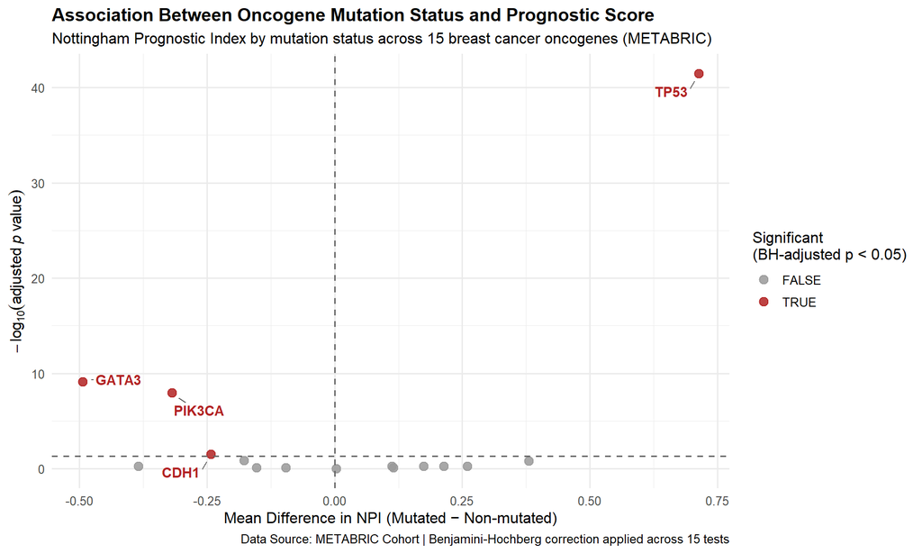

Figure 4: Association between oncogene mutation status and Nottingham Prognostic Index.

```r
ggplot(volcano_data, aes(x = mean_diff, y = neg_log10_p, color = significant)) +
  geom_point(size = 3, alpha = 0.85) +
  geom_hline(yintercept = -log10(0.05), linetype = "dashed", color = "grey40") +
  geom_vline(xintercept = 0, linetype = "dashed", color = "grey40") +
  geom_text_repel(
    data = filter(volcano_data, significant),
    aes(label = gene_label),
    fontface = "bold", show.legend = FALSE,
    box.padding = 0.6, point.padding = 0.4,
    min.segment.length = 0, segment.color = "grey40", force = 3
  ) +
  scale_color_manual(values = c("TRUE" = "firebrick", "FALSE" = "grey60")) +
  labs(
    title = "Association Between Oncogene Mutation Status and Prognostic Score",
    subtitle = "Nottingham Prognostic Index by mutation status across 15 breast cancer oncogenes (METABRIC)",
    x = "Mean Difference in NPI (Mutated − Non-mutated)",
    y = expression(-log[10](adjusted~italic(p)~value)),
    color = "Significant\n(BH-adjusted p < 0.05)",
    caption = "Data Source: METABRIC Cohort | Benjamini-Hochberg correction applied across 15 tests"
  ) +
  theme_minimal(base_size = 12) +
  theme(plot.title = element_text(face = "bold", size = 14), legend.position = "right")
```

Of the 15 genes tested, 4 remained significant after BH correction: TP53, GATA3, PIK3CA, and CDH1. TP53 mutation is associated with a *higher* NPI (mean difference = 0.71), consistent with its role as a tumor suppressor whose loss is linked to more aggressive disease. GATA3, PIK3CA, and CDH1 mutations are each associated with *lower* NPI, consistent with their association with lower-grade, often luminal or lobular breast cancer subtypes (Curtis et al., 2012).

# Limitations

- `tumor_stage` is missing for 501 patients (~26% of the cohort); analyses using this variable reflect only the staged subset.
- `tumor_size` is missing for 20 patients.
- Patients with multiple mutation events in the same gene (~10% of mutated instances, concentrated in PIK3CA and MAP3K1) were classified by a single dominant mutation type rather than split into separate events.
- Association testing uses `overall_survival_months`’s companion metric, NPI, rather than time-to-event survival analysis, since the latter requires handling censoring (patients still alive at last follow-up), which is outside the current scope.
- This analysis is exploratory and hypothesis-generating; it does not establish causality between mutation status and prognostic score.

# Future Improvements

- Proper survival analysis (Kaplan-Meier, Cox proportional hazards) using `overall_survival_months` with censoring handled correctly.
- Splitting multi-mutation cells into individual variant-level rows.
- Extending the association analysis to gene expression z-scores alongside mutation status.
- Incorporating molecular subtype (PAM50) as a covariate or stratification variable.

# References

- Curtis, C. et al. (2012). The genomic and transcriptomic architecture of 2,000 breast tumours reveals novel subgroups. *Nature*, 486, 346–352.
- Pereira, B. et al. (2016). The somatic mutation profiles of 2,433 breast cancers refine their genomic and transcriptomic landscapes. *Nature Communications*, 7, 11479.
- Data accessed via cBioPortal for Cancer Genomics (https://www.cbioportal.org/study/summary?id=brca_metabric).